# Reproduction of results from the paper

Facundo Muñoz

2016-05-04

```r
## Required packages
library(ArchaeologicalFloors)
library(geoRcb)
library(spatstat)
library(raster)
library(tidyr)
library(dplyr)
library(ggplot2)
library(ggthemes)
library(gridExtra)
library(viridis)
library(knitr)

## Plotting region
extent.india <- extent(c(6.5, 17.5, -14.5, -7.5))

## ggplot style
theme_set(theme_tufte())
```

This vignette reproduces the results from Negre et al. 2016 using the data included in the package.

We include some more results that those that made it into the paper.

On the other hand, we reproduce only the results for one of the analized variables (Calcium), as the procedure for the other is identical.

## Data description

```r
obs <- gather(Jandhala, variable, value, -(x:y))
```

```r
str(Jandhala)
```

```
## 'data.frame':    70 obs. of  4 variables:
##  $ x          : num  13 12.5 13.5 13.5 13.5 14 13.5 14 14 14 ...
##  $ y          : num  -11.5 -12 -12 -13 -11 -11.5 -10 -10.5 -13.5 -12.5 ...
##  $ Ca         : num  2.95 3.4 4.3 5.7 3.97 4.5 3.3 3.2 2.81 5.07 ...
##  $ foodremains: num  2.24 2.27 2.47 2.05 2.21 ...
```

```r
summary(Jandhala)
```

```
##        x               y                Ca         foodremains
##  Min.   : 7.50   Min.   :-13.50   Min.   :0.660   Min.   :1.339
##  1st Qu.: 9.50   1st Qu.:-12.00   1st Qu.:2.490   1st Qu.:1.826
##  Median :11.50   Median :-11.00   Median :2.945   Median :2.006
##  Mean   :11.53   Mean   :-10.99   Mean   :3.106   Mean   :2.000
##  3rd Qu.:13.50   3rd Qu.:-10.00   3rd Qu.:3.697   3rd Qu.:2.198
##  Max.   :16.00   Max.   : -8.00   Max.   :5.700   Max.   :2.675
##                                                   NA's   :3
```

```
## stat_bin: binwidth defaulted to range/30. Use 'binwidth = x' to adjust this.
## stat_bin: binwidth defaulted to range/30. Use 'binwidth = x' to adjust this.
```

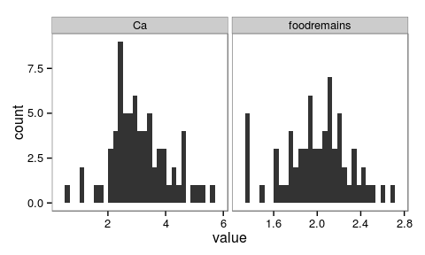

Histograms of measured variables.

```r
ggplot(obs, aes(value)) +
  geom_histogram() +
  facet_wrap(~ variable, scales = 'free_x', ncol = 2) +
  theme_bw()
```

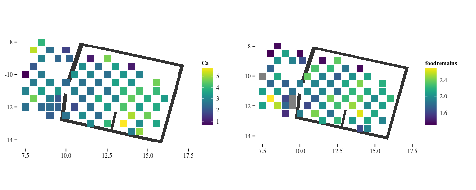

Measurement locations and observed values

```r
# plot(shp.area.trabajo)
# plot(shp.construcciones)

# shp.construcciones@data$id <- rownames(shp.construcciones@data)
# structures <- fortify(shp.construcciones, region = 'id')
# structures <- join(structures, shp.construcciones@data, by = 'id')

plot_raw_variable <- function(var) {
  p <- ggplot(NULL, aes(long, lat)) +
    geom_india() +
    scale_color_viridis()

  gp <- paste('geom_point(aes(x, y, color =',
              parse(text= var),
              '), data = Jandhala, size = 5, shape = 15)')

  p + eval(parse(text = gp))
}

p.list <- lapply(
  levels(obs$variable),
  plot_raw_variable
)
do.call('grid.arrange', c(p.list, list(ncol = 2)))
```

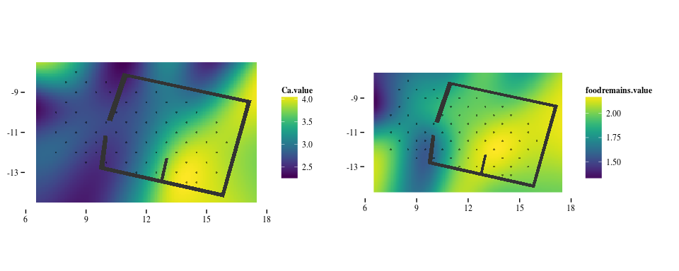

Exploratory kernel smoothing of the measurements

```r
## Create a `spatstat`'s Point Pattern object from the coordinates.
dat.ppp <- as.ppp(Jandhala,
                  owin(xrange = extent.india[1:2],
                       yrange = extent.india[3:4]))
# plot(dat.ppp)

## Relative dimensions of the region
y2x_factor <- 1/do.call('/', as.list(diff(t(bbox(extent.india)))))
dimyx <- round(128 * c(y2x_factor, 1))

smooth.im <- Smooth(dat.ppp, dimyx = dimyx, sigma = 1)
# plot(smooth.im)
smooth.dat <- as.data.frame(smooth.im)

plot_smoothed_variable <- function(var) {
  pt <- paste0('ggplot(smooth.dat, aes(', var, '.x, ', var, '.y))')
  rt <- paste0('geom_raster(aes(fill = ', var, '.value))')

  eval(parse(text = pt)) +
    eval(parse(text = rt)) +
    geom_india() +
    scale_fill_viridis()
}

p.list <- lapply(
  levels(obs$variable),
  plot_smoothed_variable
)
do.call('grid.arrange', c(p.list, list(ncol = 2)))
```

# Cost-based distances

```r
## Conductivity surface
res <- 0.05
prediction_grid <- raster(extent.india, resolution = res)
cond_surf <- rasterize(ArchaeologicalFloors:::walls,
                       prediction_grid, field = 0, background = 1)
# plot(cond_surf)
```

We use functions from the `raster` package to set up the cost surface as a raster map at a resolution of 0.05 m. We then *rasterize* the walls into this map, assigning a value of 0 to the corresponding raster cells, and a value of 1 for the rest.

This represents a **conductivity** surface (i.e. inverse cost).

```r
obs.gd <- as.geodata(Jandhala,
                     data.col=levels(obs$variable),
                     na.action = 'none')
loc <- coordinates(cond_surf)
```

```r
## Compute cost-based distances
ddm <- distmatGen(Jandhala[, c('x', 'y')], cond_surf)

## Remove prediction locations at the walls (i.e. conductivity of 0)
## since they are 'infinitely' far from everywhere
idx <- which(values(cond_surf)==0)
loc <- loc[-idx, ]
ddm$loc <- ddm$loc[-idx, ]
```

Here we set up the cost-based surface, and compute a few cost-based maps, for verifications purposes.

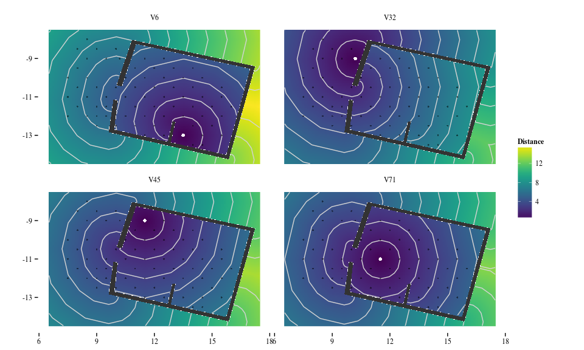

Some cost-based maps to selected observations.

```r
## Cost-based maps to each observation
cb.maps <-
  cbind(loc, ddm$loc) %>%
  as.data.frame() %>%
  gather("Observation", "Distance", -(x:y))

## Select four observations at intereseting locations
idx <- c(4, 30, 43, 69)

## Coordinates of the selected focus observations
obs.idx <- cbind(
  Jandhala[idx, ],
  Observation = factor(
    levels(cb.maps$Observation)[idx],
    levels = levels(cb.maps$Observation))
)

cb.maps %>%
  filter(Observation %in% levels(cb.maps$Observation)[idx]) %>%
  ggplot(aes(x, y)) +
  geom_raster(aes(fill = Distance, color = Distance)) +
  stat_contour(aes(z = Distance), binwidth = 1, color = 'lightgray') +
  scale_fill_viridis() +
  scale_color_viridis() +
  geom_india() +
  geom_point(data = obs.idx, col = 'white') +
  facet_wrap(~ Observation)
```

# Analysis of Calcium

```r
variable <- obs.gd$data[, 'Ca']
```

## Euclidean kriging

The variogram model is Exponential. We choose to estimate the nugget effect, which may account for measurement error, for example.

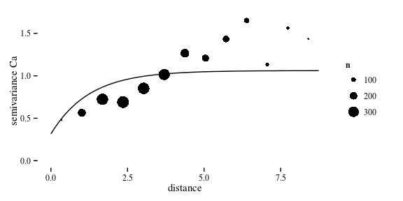

Empirical variogram and fitted model.

```r
ggplot(vg.std.Ca) +
  geom_variogram(vgmdl.std.Ca) +
  ylab('semivariance Ca')
```

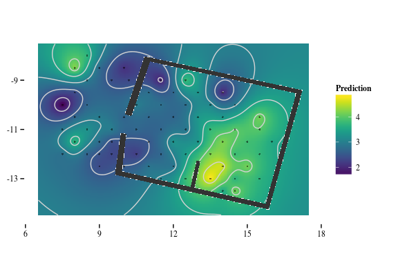

Euclidean kriging prediction

```r
p.Ca <- ggplot(data.frame(loc, Prediction = kriging.std.Ca$predict), aes(x, y)) +
  geom_raster(aes(fill = Prediction, colour = Prediction)) +
  stat_contour(aes(z = Prediction), color = 'lightgray') +
  geom_india() +
  scale_fill_viridis() +
  scale_color_viridis()
p.Ca
```

## Cost-based kriging

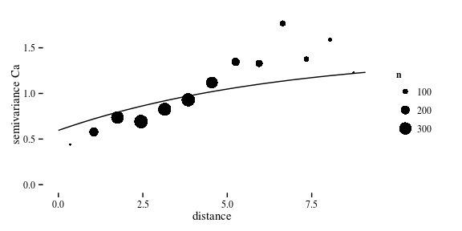

Empirical cost-based variogram and fitted model.

```r
ggplot(vg.cst.Ca) +
  geom_variogram(vgmdl.cst.Ca) +
  ylab('semivariance Ca')
```

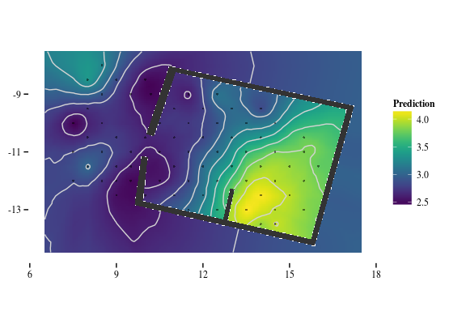

Cost-based kriging prediction

```r
p.Ca <- ggplot(data.frame(loc, Prediction = kriging.cst.Ca$predict), aes(x, y)) +
  geom_raster(aes(fill = Prediction, colour = Prediction)) +
  stat_contour(aes(z = Prediction), color = 'lightgray') +
  geom_india() +
  scale_fill_viridis() +
  scale_color_viridis()
p.Ca
```

## Comparison of method outcomes

```r
kable(par.tab, digits = 2)
```

|  | Euclidean | Cost_based |
| --- | --- | --- |
| Intercept | 3.12 | 3.17 |
| Nugget | 0.32 | 0.60 |
| Partial sill | 0.75 | 0.85 |
| phi | 1.25 | 6.53 |
| Pract. range | 3.75 | 19.56 |
| Log-likelihood | -89.25 | -89.82 |

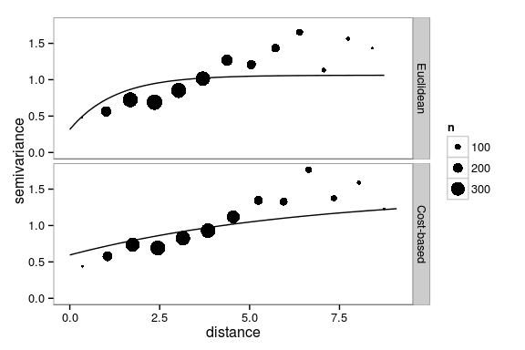

Empirical variogram and fitted models by method for Calcium.

```r
vg.both <- rbind(data.frame(vg.std.Ca[1:3],
                            variable = 'Ca',
                            method = 'Euclidean'),
                 data.frame(vg.cst.Ca[1:3],
                            variable = 'Ca',
                            method = 'Cost-based'))

names(vg.both) <- c('distance', 'semivariance', 'n', 'variable', 'method')

p.Ca <- ggplot(vg.both, aes(distance, semivariance)) +
  geom_point(aes(size = n)) +
  expand_limits(y=0) +
  geom_variogram(vgmdl.std.Ca, variable = 'Ca', method = 'Euclidean') +
  geom_variogram(vgmdl.cst.Ca, variable = 'Ca', method = 'Cost-based') +
  facet_grid(method ~ .) +
  theme_bw()

p.Ca
```

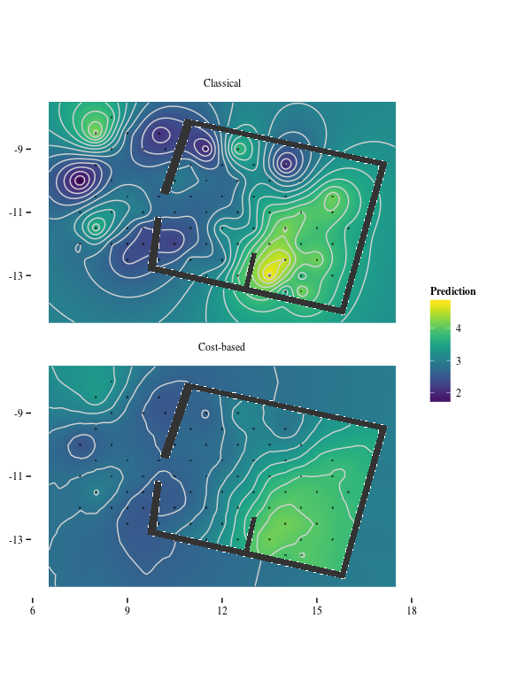

Comparison of Kriging estimates.

```r
res.df.Ca <- data.frame(
  loc,
  method = c(rep('Classical', nrow(loc)),
             rep('Cost-based', nrow(loc)),
             rep('Difference', nrow(loc))),
  Prediction = c(kriging.std.Ca$predict,
                 kriging.cst.Ca$predict,
                 kriging.std.Ca$predict-kriging.cst.Ca$predict)
)


p.Ca <-
  ggplot(filter(res.df.Ca, method != 'Difference'),
         aes(x, y)) +
  geom_raster(aes(fill = Prediction, colour = Prediction)) +
  stat_contour(aes(z = Prediction), binwidth = .2, color = 'lightgray') +
  geom_india() +
  scale_fill_viridis() +
  scale_color_viridis() +
  facet_wrap(~method, ncol = 1)
p.Ca
```

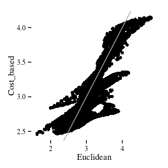

Pointwise comparison of predictions by method.

```r
## Only represent a random sample of all 30k prediction points
p.Ca <- data.frame(Euclidean  = kriging.std.Ca$predict,
                   Cost_based = kriging.cst.Ca$predict,
                   variable   = 'Ca') %>%
  sample_n(5e3) %>%
  ggplot(aes(Euclidean, Cost_based)) +
  geom_point() +
  geom_abline(intercept = 0, slope = 1, col = 'darkgray')


p.Ca
```

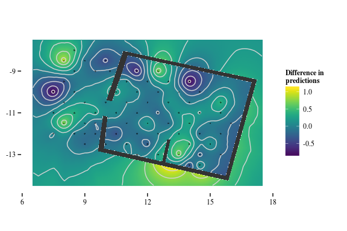

Difference between the Euclidean and the cost-based predictions.

```r
pred.dif.Ca <-
  ggplot(filter(res.df.Ca, method == 'Difference'),
         aes(x, y)) +
  geom_tile(aes(fill = Prediction, colour = Prediction)) +
  stat_contour(aes(z = Prediction), binwidth = .2, color = 'lightgray') +
  geom_india() +
  scale_fill_viridis(name = 'Difference in\npredictions') +
  scale_color_viridis(name = 'Difference in\npredictions')
pred.dif.Ca
```

```r
# grid.arrange(pred.comp, pred.dif)
```

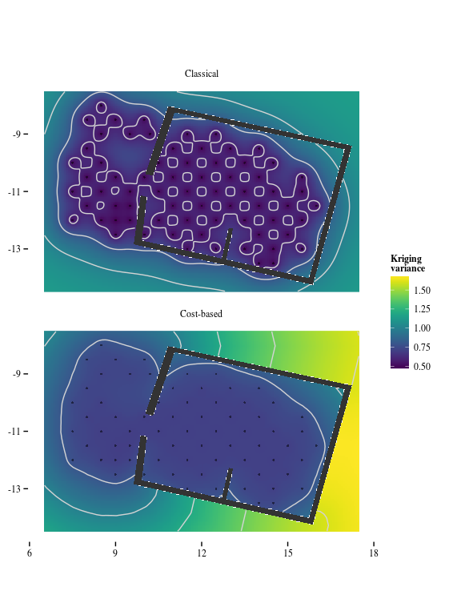

Comparison of prediction error by method.

```r
res.var.Ca <- data.frame(
  loc,
  method = c(rep('Classical', nrow(loc)),
             rep('Cost-based', nrow(loc)),
             rep('Difference', nrow(loc))),
  Prediction = c(kriging.std.Ca$krige.var,
                 kriging.cst.Ca$krige.var,
                 kriging.std.Ca$krige.var-kriging.cst.Ca$krige.var)
)

ggplot(filter(res.var.Ca, method != 'Difference'),
         aes(x, y)) +
  geom_raster(aes(fill = Prediction, colour = Prediction)) +
  stat_contour(aes(z = Prediction), binwidth = .2, color = 'lightgray') +
  geom_india() +
  scale_fill_viridis(name = 'Kriging\nvariance') +
  scale_color_viridis(name = 'Kriging\nvariance') +
  facet_wrap(~method, ncol = 1)
```

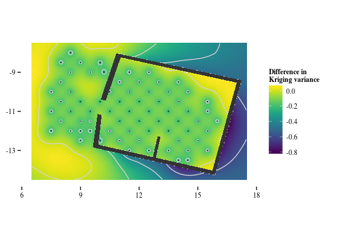

Difference between the Euclidean and the cost-based prediction errors

```r
ggplot(filter(res.var.Ca, method == 'Difference'),
         aes(x, y)) +
  geom_tile(aes(fill = Prediction, colour = Prediction)) +
  stat_contour(aes(z = Prediction), binwidth = .2, color = 'lightgray') +
  geom_india() +
  scale_fill_viridis(name = 'Difference in\nKriging variance') +
  scale_color_viridis(name = 'Difference in\nKriging variance')
```

Near the observations, the cost-based approach has a larger prediction error due to its increased estimation of the nugget (i.e. short-range variance). In the main area, the prediction errors are practically the same with both approaches. Behind the walls, the Euclidean prediction error is unrealistically low.

## Leave-one-out Cross Validation (LOOCV)

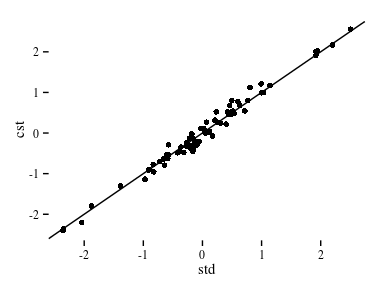

Pointwise leave-one-out prediction error by method.

```r
loocvdat <- obs.gd
loocvdat$data <- variable
res <- sapply(c('std', 'cst'), krige.loocv, loocvdat, ddm)

pred_error <- data.frame(
  std = loocvdat$data - res[, 1],
  cst = loocvdat$data - res[, 2]
)

ggplot(pred_error, aes(std, cst)) +
  geom_point() +
  geom_abline(intercept = 0, slope = 1)
```

```r
rmse <- function(x) sqrt(mean(x**2))

pred_error %>%
  gather(method, error) %>%
  group_by(method) %>%
  summarise(rmse(error)) %>%
  kable(digits = 2)
```

| method | rmse(error) |
| --- | --- |
| std | 0.93 |
| cst | 0.96 |